# ECE 57000 Assignment 3 Exercise

Your Name: Manish Kumar Krishne Gowda

Prepare the pacakge we will use.

```python
from google.colab import drive
drive.mount('/content/drive')
```

```python
!pwd
```

```
/content
```

```python
import time
import os

from typing import List, Dict

import torch
import torch.nn as nn
import torch.optim as optim
import torch.nn.functional as F
import torchvision
import torchvision.models as models
import torchvision.transforms as transforms

import matplotlib.pyplot as plt
import pickle
```

## Exercise 0: Train your model on GPU (0 points)

Some tasks in this assignment can take a long time if you run it on the CPU. For example, based on our solution of Exercise 3 Task 4 (Transfer Learning: finetuning of a pretrained model (resnet18)), it will take roughly 2 hours to train the model end-to-end (complete model and not only the last fc layer) for 1 epoch on CPU. Hence, we highly recommend you try to train your model on GPU.

To do so, first you need to enable GPU on Colab (this will restart the runtime). Click `Runtime`-> `Change runtime type` and select the `Hardware accelerator` there. You can then run the following code to see if the GPU is correctly initialized and available.

**Note**: If you would like to avoid GPU overages on Colab, we would suggest writing and debugging your code before switching on the GPU runtime. Otherwise, the time you spent debugging code will likely count against your GPU usage. Once you have the code running, you can switch on the GPU runtime and train the model much faster.

```python
print(f'Can I can use GPU now? -- {torch.cuda.is_available()}')
```

```
Can I can use GPU now? -- True
```

### You must manually move your model and data to the GPU (and sometimes back to the cpu)

After setting the GPU up on colab, then you should put your **model** and **data** to GPU. We give a simple example below. You can use `to` function for this task. See [torch.Tensor.to](https://pytorch.org/docs/stable/generated/torch.Tensor.to.html) to move a tensor to the GPU (probably your mini-batch of data in each iteration) or torch.nn.Module.to to move your NN model to GPU (assuming you create subclass [torch.nn.Module](https://pytorch.org/docs/stable/generated/torch.nn.Module.html)). Note that `to()` of tensor returns a NEW tensor while `to` of a NN model will apply this in-place. To be safe, the best semantics are `obj = obj.to(device)`. For printing, you will need to move a tensor back to the CPU via the `cpu()` function.

Once the model and input data are on the GPU, everything else can be done the same. This is the beauty of PyTorch GPU acceleration. None of the other code needs to be altered.

To summarize, you need to 1) enable GPU acceleration in Colab, 2) put the model on the GPU, and 3) put the input data (i.e., the batch of samples) onto the GPU using `to()` after it is loaded by the data loaders (usually you only put one batch of data on the GPU at a time).

```python
rand_tensor = torch.rand(5,2)
simple_model = nn.Sequential(nn.Linear(2,10), nn.ReLU(), nn.Linear(10,1))
print(f'input is on {rand_tensor.device}')
print(f'model parameters are on {[param.device for param in simple_model.parameters()]}')
print(f'output is on {simple_model(rand_tensor).device}')

# device = torch.device('cuda')

device = torch.device('cuda' if torch.cuda.is_available() else 'cpu')
# ----------- <Your code> ---------------
# Move rand_tensor and model onto the GPU device
rand_tensor = rand_tensor.to(device)
simple_model = simple_model.to(device)

# --------- <End your code> -------------
print(f'input is on {rand_tensor.device}')
print(f'model parameters are on {[param.device for param in simple_model.parameters()]}')
print(f'output is on {simple_model(rand_tensor).device}')
```

```
input is on cpu
model parameters are on [device(type='cpu'), device(type='cpu'), device(type='cpu'), device(type='cpu')]
output is on cpu
input is on cuda:0
model parameters are on [device(type='cuda', index=0), device(type='cuda', index=0), device(type='cuda', index=0), device(type='cuda', index=0)]
output is on cuda:0
```

```python
total_params = sum(p.numel() for p in simple_model.parameters())
print(f'Number of parameters: {total_params}')
```

```
Number of parameters: 41
```

## Exercise 1: Why use a CNN rather than only fully connected layers? (40 points)

In this exercise, you will build two models for the **MNIST** dataset: one uses only fully connected layers and another uses a standard CNN layout (convolution layers everywhere except the last layer is fully connected layer). Note, you will need to use cross entropy loss as your objective function. The two models should be built with roughly the same accuracy performance, your task is to compare the number of network parameters (a huge number of parameters can affect training/testing time, memory requirements, overfitting, etc.).

### Task 1: Prepare train and test function

We will create our train and test procedure in these two functions. The train function should apply one epoch of training. The functions inputs should take everything we need for training and testing and return some logs.

#### Arguments requirement:

- For the `train` function, it takes the `model`, `loss_fn`, `optimizer`, `train_loader`, and `epoch` as arguments.
  - `model`: the classifier, or deep neural network, should be an instance of `nn.Module`.
  - `loss_fn`: the loss function instance. For example, `nn.CrossEntropy()`, or `nn.L1Loss()`, etc.
  - `optimizer`: should be an instance of `torch.optim.Optimizer`. For example, it could be `optim.SGD()` or `optim.Adam()`, etc.
  - `train_loader`: should be an instance of `torch.utils.data.DataLoader`.
  - `epoch`: the current number of epoch. Only used for log printing.(default: 1.)
- For the `test` function, it takes all the inputs above except for the optimizer (and it takes a test loader instead of a train loader).

#### Log requirement:

Here are some further requirements:

- In the `train` function, print the log 8-10 times per epoch. The print statement should be:

  ```
  print(f'Epoch {epoch}: [{batch_idx*len(images)}/{len(train_loader.dataset)}] Loss: {loss.item():.3f}')
  ```

- In the `test` function, print the log after the testing. The print statement is:

  ```
  print(f"Test result on epoch {epoch}: total sample: {total_num}, Avg loss: {test_stat['loss']:.3f}, Acc: {100*test_stat['accuracy']:.3f}%")
  ```

#### Return requirement

- The `train` function should return a list, which the element is the loss per batch, i.e., one loss value for every batch.
- The `test` function should return a dictionary with three keys: "loss", "accuracy", and "prediction". The values are the average loss of all the testset, average accuracy of all the test dataset, and the prediction of all test dataset.

#### Other requirement:

- In the `train` function, the model should be updated in-place, i.e., do not copy the model inside `train` function.

```python
def train(model: nn.Module,
          loss_fn: nn.modules.loss._Loss,
          optimizer: torch.optim.Optimizer,
          train_loader: torch.utils.data.DataLoader,
          epoch: int=0)-> List:
    # ----------- <Your code> ---------------
    model.train()  # Set the model to training mode
    train_loss = []  # To store loss for each batch

    # Loop over batches
    for batch_idx, (images, targets) in enumerate(train_loader):
        # Zero the gradients before forward pass
        optimizer.zero_grad()

        # Forward pass: compute predictions and loss
        outputs = model(images)
        loss = loss_fn(outputs, targets)

        # Backward pass: compute gradients
        loss.backward()

        # Update weights using optimizer
        optimizer.step()

        # Store loss for this batch
        train_loss.append(loss.item())

        # Print log 8-10 times per epoch
        if batch_idx % (len(train_loader) // 10) == 0:
            print(f'Epoch {epoch}: [{batch_idx*len(images)}/{len(train_loader.dataset)}] Loss: {loss.item():.3f}')
    # ----------- <End Your code> ---------------
    assert len(train_loss) == len(train_loader)
    return train_loss

def test(model: nn.Module,
         loss_fn: nn.modules.loss._Loss,
         test_loader: torch.utils.data.DataLoader,
         epoch: int=0)-> Dict:
    # ----------- <Your code> ---------------
    model.eval()  # Set the model to evaluation mode
    test_loss = 0.0
    correct = 0
    predictions = []
    # Disable gradient computation for testing
    with torch.no_grad():
        for images, targets in test_loader:
            # Forward pass: compute predictions
            outputs = model(images)

            # Compute loss
            loss = loss_fn(outputs, targets)
            test_loss += loss.item()  # Accumulate the total loss

            # Get predictions: assuming classification task
            pred = outputs.argmax(dim=1, keepdim=True)  # Get index of the max log-probability
            predictions.append(pred.flatten())

            # Count correct predictions
            correct += pred.eq(targets.view_as(pred)).sum().item()

    # Convert predictions list to a 1D tensor
    predictions = torch.cat(predictions)

    # Average loss over all test data
    test_loss /= len(test_loader)

    # Accuracy calculation
    accuracy = correct / len(test_loader.dataset)

    # Create dictionary with test statistics
    test_stat = {
        "loss": test_loss,
        "accuracy": accuracy,
        "prediction": predictions
    }
    # ----------- <Your code> ---------------
    # dictionary should include loss, accuracy and prediction
    assert "loss" and "accuracy" and "prediction" in test_stat.keys()
    # "prediction" value should be a 1D tensor
    assert len(test_stat["prediction"]) == len(test_loader.dataset)
    assert isinstance(test_stat["prediction"], torch.Tensor)
    return test_stat
```

### Task 2: Following the structure used in the instructions, you should create

- One network named `OurFC` which should consist with only fully connected layers
  - You should decide how many layers and how many hidden dimensions you want in your network
  - Your final accuracy on the test dataset should lie roughly around 97% ($\pm$2%)
  - There is no need to make the neural network unnecessarily complex, your total training time should no longer than 3 mins
- Another network named `OurCNN` which applys a standard CNN structure
  - Again, you should decide how many layers and how many channels you want for each layer.
  - Your final accuracy on the test dataset should lie roughly around 97% ($\pm$2%)
  - A standard CNN structure can be composed as **[Conv2d, MaxPooling, ReLU] x num_conv_layers + FC x num_fc_layers**
- Train and test your network on MNIST data as in the instructions.
- Notice You can always use the `train` and `test` function you write throughout this assignment.
- The code below will also print out the number of parameters for both neural networks to allow comparison.
- (You can use multiple cells if helpful but make sure to run all of them to receive credit.)

```python
# Download MNIST and transformation
# ----------- <Your code> ---------------
import torchvision

"""
Here the transform is a pipeline containing two seperate transforms:
1. Transform the data into tensor type
2. Normalize the dataset by a giving mean and std.
  (Those number is given as the global mean and standard deviation of MNIST dataset)
"""
transform = torchvision.transforms.Compose([torchvision.transforms.ToTensor(),
                      torchvision.transforms.Normalize((0.1307,),(0.3081,))])

train_dataset = torchvision.datasets.MNIST('data', train=True, download=True, transform=transform)
test_dataset = torchvision.datasets.MNIST('data', train=False, download=True, transform=transform)
# ----------- <End Your code> -------------
```

[output not shown]

[output not shown]

[output not shown]

[output not shown]

[output not shown]

```python
print(train_dataset)
print(test_dataset)

batch_size_train, batch_size_test = 64, 1000

train_loader = torch.utils.data.DataLoader(train_dataset, batch_size=batch_size_train, shuffle=True)
test_loader = torch.utils.data.DataLoader(test_dataset, batch_size=batch_size_test, shuffle=False)

print(train_loader)
batch_idx, (images, targets) = next(enumerate(train_loader))
print(f'current batch index is {batch_idx}')
print(f'images has shape {images.size()}')
print(f'targets has shape {targets.size()}')
```

```
Dataset MNIST
    Number of datapoints: 60000
    Root location: data
    Split: Train
    StandardTransform
Transform: Compose(
               ToTensor()
               Normalize(mean=(0.1307,), std=(0.3081,))
           )
Dataset MNIST
    Number of datapoints: 10000
    Root location: data
    Split: Test
    StandardTransform
Transform: Compose(
               ToTensor()
               Normalize(mean=(0.1307,), std=(0.3081,))
           )
<torch.utils.data.dataloader.DataLoader object at 0x7d894c7e27a0>
current batch index is 0
images has shape torch.Size([64, 1, 28, 28])
targets has shape torch.Size([64])
```

```python
# Build OurFC class and OurCNN class.
# ----------- <Your code> ---------------
import torch.nn as nn
import torch.nn.functional as F

class OurCNN(nn.Module):
    def __init__(self):
        super(OurCNN, self).__init__()

        # Define two convolutional layers
        self.conv1 = nn.Conv2d(1, 3, kernel_size=3)  # First conv layer
        self.conv2 = nn.Conv2d(3, 3, kernel_size=3)  # Second conv layer

        # Define fully connected layer
        # After conv2, the image size is reduced to 11x11. 3 channels from conv2, and 3*11*11 = 363.
        self.fc = nn.Linear(3 * 11 * 11, 10)

    def forward(self, x):
        # First convolutional layer with relu and max pooling
        x = self.conv1(x)                        # x shape: (batch_size, 3, 26, 26)
        x = F.relu(F.max_pool2d(x, 2))           # x shape: (batch_size, 3, 13, 13)

        # Second convolutional layer with relu (no pooling after this one)
        x = self.conv2(x)                        # x shape: (batch_size, 3, 11, 11)

        # Flatten the tensor for the fully connected layer
        x = x.view(-1, 3 * 11 * 11)              # x shape: (batch_size, 363)

        # Fully connected layer with relu
        x = F.relu(self.fc(x))                   # x shape: (batch_size, 10)

        # Log softmax for the output
        return F.log_softmax(x, dim=-1)

class OurFC(nn.Module):
    def __init__(self):
        super(OurFC, self).__init__()
        # Define fully connected layers
        self.flatten = nn.Flatten()  # Flatten the 28x28 input images to a 1D vector
        self.fc1 = nn.Linear(28 * 28, 363)  # First hidden layer
        self.fc2 = nn.Linear(363, 363)      # Second hidden layer
        self.fc3 = nn.Linear(363, 363)      # Third hidden layer
        self.output = nn.Linear(363, 10)    # Output layer (10 classes for classification)

        # Define activation function (ReLU is commonly used for hidden layers)
        self.relu = nn.ReLU()

    def forward(self, x):
        # Forward pass through the network
        x = self.flatten(x)      # Flatten the input image
        x = self.relu(self.fc1(x))  # First hidden layer + activation
        x = self.relu(self.fc2(x))  # Second hidden layer + activation
        x = self.relu(self.fc3(x))  # Third hidden layer + activation
        x = self.output(x)          # Output layer (no activation because it's for classification)
        return x
# ----------- <End Your code> -------------
```

```python
# Let's first train the FC model. Below are there common hyperparameters.
# ----------- <Your code> ---------------
criterion = nn.CrossEntropyLoss()
max_epoch = 3
model = OurFC()
optimizer = optim.SGD(model.parameters(), lr=0.01, momentum=0.9)  # SGD with momentum
# File paths for saving model and losses
model_file = '/content/drive/MyDrive/ECE57000_AI/Assignment_03/model.pth'
loss_file = '/content/drive/MyDrive/ECE57000_AI/Assignment_03/train_loss.pkl'

if os.path.exists(model_file) and os.path.exists(loss_file):
    model.load_state_dict(torch.load(model_file))  # Load model weights
    with open(loss_file, 'rb') as f:
        train_losses = pickle.load(f)  # Load training losses
else:
    train_losses = []  # Initialize list if not present

start = time.time()
for epoch in range(1, max_epoch + 1):
    epoch_loss = train(model, criterion, optimizer, train_loader, epoch)
    train_losses.append(epoch_loss)  # Append the loss for this epoch

    # Save the model after each epoch
    torch.save(model.state_dict(), model_file)

# Save the training losses to a file
with open(loss_file, 'wb') as f:
    pickle.dump(train_losses, f)
# ----------- <End Your code> ---------------
end = time.time()
print(f'Finished Training after {end-start} s')
```

```
Epoch 1: [0/60000] Loss: 2.298
Epoch 1: [5952/60000] Loss: 0.520
Epoch 1: [11904/60000] Loss: 0.214
Epoch 1: [17856/60000] Loss: 0.068
Epoch 1: [23808/60000] Loss: 0.148
Epoch 1: [29760/60000] Loss: 0.240
Epoch 1: [35712/60000] Loss: 0.338
Epoch 1: [41664/60000] Loss: 0.099
Epoch 1: [47616/60000] Loss: 0.195
Epoch 1: [53568/60000] Loss: 0.139
Epoch 1: [59520/60000] Loss: 0.132
Epoch 2: [0/60000] Loss: 0.117
Epoch 2: [5952/60000] Loss: 0.103
Epoch 2: [11904/60000] Loss: 0.175
Epoch 2: [17856/60000] Loss: 0.109
Epoch 2: [23808/60000] Loss: 0.231
Epoch 2: [29760/60000] Loss: 0.109
Epoch 2: [35712/60000] Loss: 0.048
Epoch 2: [41664/60000] Loss: 0.073
Epoch 2: [47616/60000] Loss: 0.062
Epoch 2: [53568/60000] Loss: 0.165
Epoch 2: [59520/60000] Loss: 0.093
Epoch 3: [0/60000] Loss: 0.107
Epoch 3: [5952/60000] Loss: 0.048
Epoch 3: [11904/60000] Loss: 0.060
Epoch 3: [17856/60000] Loss: 0.076
Epoch 3: [23808/60000] Loss: 0.025
Epoch 3: [29760/60000] Loss: 0.028
Epoch 3: [35712/60000] Loss: 0.027
Epoch 3: [41664/60000] Loss: 0.136
Epoch 3: [47616/60000] Loss: 0.095
Epoch 3: [53568/60000] Loss: 0.059
Epoch 3: [59520/60000] Loss: 0.052
Finished Training after 45.72572946548462 s
```

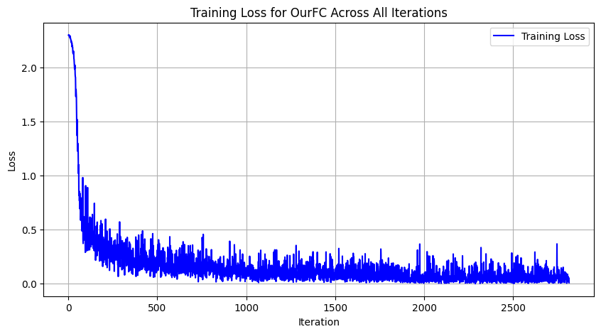

```python
# File paths for loading the model and losses
model_file = '/content/drive/MyDrive/ECE57000_AI/Assignment_03/model.pth'
loss_file = '/content/drive/MyDrive/ECE57000_AI/Assignment_03/train_loss.pkl'

# Initialize the model
model = OurFC()

# Load the trained model weights
model.load_state_dict(torch.load(model_file))
model.eval()  # Set the model to evaluation mode

# Load training losses
with open(loss_file, 'rb') as f:
    train_losses = pickle.load(f)

# Flatten the training losses across all epochs
flattened_losses = [loss for epoch_loss in train_losses for loss in epoch_loss]

# Calculate the total number of iterations (assuming batch size is known)
# You may need to replace `batch_size` with your actual batch size
total_iterations = len(flattened_losses)

# Generate x-axis values (iterations)
x_values = range(1, total_iterations + 1)

# Plot the training losses
plt.figure(figsize=(10, 5))
plt.plot(x_values, flattened_losses, label='Training Loss', color='blue')
plt.title('Training Loss for OurFC Across All Iterations')
plt.xlabel('Iteration')
plt.ylabel('Loss')
plt.grid()
plt.legend()
plt.show()
```

```python
# File paths for loading model and losses
model_file = '/content/drive/MyDrive/ECE57000_AI/Assignment_03/model.pth'
# Initialize the model
criterion = nn.CrossEntropyLoss()
model = OurFC()
# Load the trained model for testing
model.load_state_dict(torch.load(model_file))
model.eval()  # Set the model to evaluation mode

# Testing the model
test_stat  = test(model, criterion, test_loader)

# Print the testing loss and accuracy
print(f'Test Loss: {test_stat["loss"]:.3f}')
print(f'Test Accuracy: {test_stat["accuracy"]*100:.2f}%')
```

```
Test Loss: 0.075
Test Accuracy: 97.64%
```

```python
# Let's then train the OurCNN model.
# ----------- <Your code> ---------------
model_cnn = OurCNN()
# Hyperparameters
criterion = nn.CrossEntropyLoss()
optimizer = optim.SGD(model_cnn.parameters(), lr=0.01, momentum=0.9)  # SGD with momentum
max_epoch = 3

# File paths for saving model and losses
model_cnn_file = '/content/drive/MyDrive/ECE57000_AI/Assignment_03/cnn_model.pth'
cnn_loss_file = '/content/drive/MyDrive/ECE57000_AI/Assignment_03/cnn_train_loss.pkl'

# Load model and losses if they exist
if os.path.exists(model_cnn_file) and os.path.exists(cnn_loss_file):
    model_cnn.load_state_dict(torch.load(model_cnn_file))  # Load model weights
    with open(cnn_loss_file, 'rb') as f:
        cnn_train_losses = pickle.load(f)  # Load training losses
else:
    cnn_train_losses = []  # Initialize list if not present

start = time.time()

for epoch in range(1, max_epoch + 1):
    epoch_loss = train(model_cnn, criterion, optimizer, train_loader, epoch)
    cnn_train_losses.append(epoch_loss)  # Append the loss for this epoch

    # Save the model after each epoch
    torch.save(model_cnn.state_dict(), model_cnn_file)

# Save the training losses to a file
with open(cnn_loss_file, 'wb') as f:
    pickle.dump(cnn_train_losses, f)
# ----------- <End Your code> ---------------
end = time.time()
print(f'Finished Training after {end-start} s ')
```

```
Epoch 1: [0/60000] Loss: 2.395
Epoch 1: [5952/60000] Loss: 0.381
Epoch 1: [11904/60000] Loss: 0.318
Epoch 1: [17856/60000] Loss: 0.413
Epoch 1: [23808/60000] Loss: 0.169
Epoch 1: [29760/60000] Loss: 0.565
Epoch 1: [35712/60000] Loss: 0.127
Epoch 1: [41664/60000] Loss: 0.120
Epoch 1: [47616/60000] Loss: 0.126
Epoch 1: [53568/60000] Loss: 0.211
Epoch 1: [59520/60000] Loss: 0.109
Epoch 2: [0/60000] Loss: 0.082
Epoch 2: [5952/60000] Loss: 0.281
Epoch 2: [11904/60000] Loss: 0.159
Epoch 2: [17856/60000] Loss: 0.178
Epoch 2: [23808/60000] Loss: 0.147
Epoch 2: [29760/60000] Loss: 0.065
Epoch 2: [35712/60000] Loss: 0.124
Epoch 2: [41664/60000] Loss: 0.097
Epoch 2: [47616/60000] Loss: 0.151
Epoch 2: [53568/60000] Loss: 0.048
Epoch 2: [59520/60000] Loss: 0.054
Epoch 3: [0/60000] Loss: 0.126
Epoch 3: [5952/60000] Loss: 0.152
Epoch 3: [11904/60000] Loss: 0.044
Epoch 3: [17856/60000] Loss: 0.046
Epoch 3: [23808/60000] Loss: 0.078
Epoch 3: [29760/60000] Loss: 0.079
Epoch 3: [35712/60000] Loss: 0.031
Epoch 3: [41664/60000] Loss: 0.077
Epoch 3: [47616/60000] Loss: 0.117
Epoch 3: [53568/60000] Loss: 0.220
Epoch 3: [59520/60000] Loss: 0.170
Finished Training after 49.88678979873657 s
```

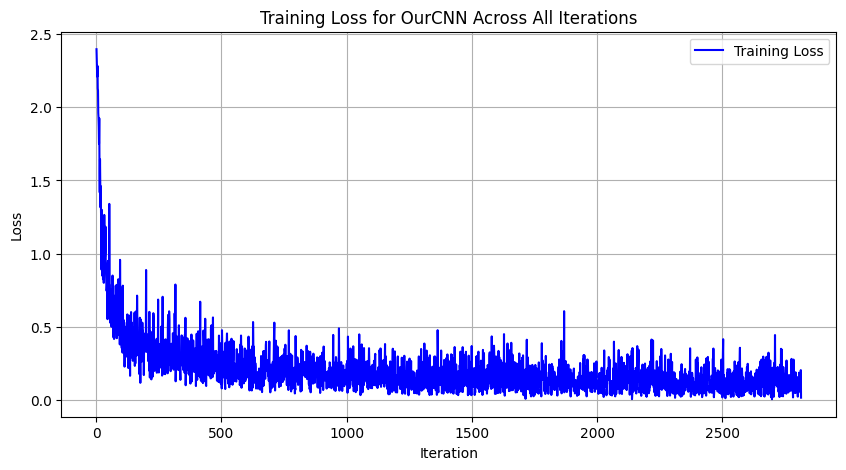

```python
# File paths for loading the model and losses
model_cnn_file = '/content/drive/MyDrive/ECE57000_AI/Assignment_03/cnn_model.pth'
cnn_loss_file = '/content/drive/MyDrive/ECE57000_AI/Assignment_03/cnn_train_loss.pkl'

# Initialize the model
model = OurCNN()

# Load the trained model weights
model.load_state_dict(torch.load(model_cnn_file))
model.eval()  # Set the model to evaluation mode

# Load training losses
with open(cnn_loss_file, 'rb') as f:
    train_losses = pickle.load(f)

# Flatten the training losses across all epochs
flattened_losses = [loss for epoch_loss in train_losses for loss in epoch_loss]

# Calculate the total number of iterations (assuming batch size is known)
# You may need to replace `batch_size` with your actual batch size
total_iterations = len(flattened_losses)

# Generate x-axis values (iterations)
x_values = range(1, total_iterations + 1)

# Plot the training losses
plt.figure(figsize=(10, 5))
plt.plot(x_values, flattened_losses, label='Training Loss', color='blue')
plt.title('Training Loss for OurCNN Across All Iterations')
plt.xlabel('Iteration')
plt.ylabel('Loss')
plt.grid()
plt.legend()
plt.show()
```

```python
# File paths for loading model and losses
model_cnn_file = '/content/drive/MyDrive/ECE57000_AI/Assignment_03/cnn_model.pth'
criterion = nn.CrossEntropyLoss()
# Initialize the model
model = OurCNN()
# Load the trained model for testing
model.load_state_dict(torch.load(model_cnn_file))
model.eval()  # Set the model to evaluation mode

# Testing the model
test_stat  = test(model, criterion, test_loader)

# Print the testing loss and accuracy
print(f'Test Loss: {test_stat["loss"]:.3f}')
print(f'Test Accuracy: {test_stat["accuracy"]*100:.2f}%')
```

```
Test Loss: 0.116
Test Accuracy: 96.53%
```

```python
ourfc = OurFC()
total_params = sum(p.numel() for p in ourfc.parameters())
print(f'OurFC has a total of {total_params} parameters')

ourcnn = OurCNN()
total_params = sum(p.numel() for p in ourcnn.parameters())
print(f'OurCNN has a total of {total_params} parameters')
```

```
OurFC has a total of 552859 parameters
OurCNN has a total of 3754 parameters
```

Questions (0 points, just for understanding): Which one has more parameters? Which one is likely to have less computational cost when deployed? Which one took longer to train?

OurFC has more parameters (552,859) compared to OurCNN (3,754). OurCNN is likely to have less computational cost when deployed due to fewer parameters. OurCNN took longer to train, however usually CNNs take lesser times compared to FCNNs for same number of layers. The difference here is likely due to too few parameters and layers to make full utilisation of GPU capabilities

## Exercise 2: Train classifier on CIFAR-10 data. (30 points)

Now, lets move our dataset to color images. CIFAR-10 dataset is another widely used dataset. Here all images have colors, i.e each image has 3 color channels instead of only one channel in MNIST. You need to pay more attention to the dimension of the data as it passes through the layers of your network.

### Task 1: Create data loaders

- Load CIFAR10 train and test datas with appropriate composite transform where the normalize transform should be `transforms.Normalize((0.5, 0.5, 0.5), (0.5, 0.5, 0.5))])`.
- Set up a `train_loader` and `test_loader` for the CIFAR-10 data with a batch size of 9 similar to the instructions.
- The code below will plot a 3 x 3 subplot of images including their labels. (do not modify)

```
Files already downloaded and verified
Files already downloaded and verified
```

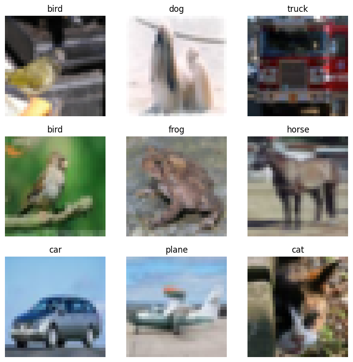

```python
classes = ('plane', 'car', 'bird', 'cat', 'deer', 'dog', 'frog', 'horse', 'ship', 'truck')

# Create the appropriate transform, load/download CIFAR10 train and test datasets with transform
# ----------- <Your code> ---------------
# Define the composite transform
transform = transforms.Compose([
    transforms.ToTensor(),  # Convert images to PyTorch tensors
    transforms.Normalize((0.5, 0.5, 0.5), (0.5, 0.5, 0.5))  # Normalize with mean and std
])

# Load and download CIFAR10 train and test datasets
train_dataset = torchvision.datasets.CIFAR10(root='./data', train=True, download=True, transform=transform)
test_dataset = torchvision.datasets.CIFAR10(root='./data', train=False, download=True, transform=transform)
# ----------- <End Your code> ---------------

# Define trainloader and testloader
# ----------- <Your code> ---------------
batch_size = 9

train_loader = torch.utils.data.DataLoader(train_dataset, batch_size=batch_size, shuffle=True)
test_loader = torch.utils.data.DataLoader(test_dataset, batch_size=batch_size, shuffle=False)
# ----------- <End Your code> ---------------

# Code to display images
batch_idx, (images, targets) = next(enumerate(train_loader)) #fix!!!!!
fig, ax = plt.subplots(3,3,figsize = (9,9))
for i in range(3):
    for j in range(3):
        image = images[i*3+j].permute(1,2,0)
        image = image/2 + 0.5
        ax[i,j].imshow(image)
        ax[i,j].set_axis_off()
        ax[i,j].set_title(f'{classes[targets[i*3+j]]}')
fig.show()
```

```python
print(train_loader)
batch_idx, (images, targets) = next(enumerate(train_loader))
print(f'current batch index is {batch_idx}')
print(f'images has shape {images.size()}')
print(f'targets has shape {targets.size()}')
```

```
<torch.utils.data.dataloader.DataLoader object at 0x7c49d1191780>
current batch index is 0
images has shape torch.Size([9, 3, 32, 32])
targets has shape torch.Size([9])
```

### Task 2: Create CNN and train it

Set up a convolutional neural network and have your data trained on it. You have to decide all the details in your network, overall your neural network should meet the following standards to receive full credit:

- You should not use more than three convolutional layers and three fully connected layers
- Accuracy on the test dataset should be **above** 50%

```python
import torch
import torch.nn as nn
import torch.nn.functional as F

# Create CNN network.
# ----------- <Your code> ---------------
class OurCIFARCNN(nn.Module):
    def __init__(self):
        super(OurCIFARCNN, self).__init__()

        # Define three convolutional layers
        self.conv1 = nn.Conv2d(3, 16, kernel_size=3)  # First conv layer
        self.bn1 = nn.BatchNorm2d(16)                 # Batch normalization for the first conv layer

        self.conv2 = nn.Conv2d(16, 32, kernel_size=3) # Second conv layer
        self.bn2 = nn.BatchNorm2d(32)                 # Batch normalization for the second conv layer

        self.conv3 = nn.Conv2d(32, 64, kernel_size=3) # Third conv layer
        self.bn3 = nn.BatchNorm2d(64)                 # Batch normalization for the third conv layer

        # Define fully connected layers
        self.fc1 = nn.Linear(64 * 4 * 4, 256)        # First fully connected layer
        self.fc2 = nn.Linear(256, 128)               # Second fully connected layer
        self.fc3 = nn.Linear(128, 10)                # Output layer

    def forward(self, x):
        # First convolutional layer with batch normalization, relu, and max pooling
        x = self.conv1(x)                        # x shape: (batch_size, 16, 30, 30)
        x = self.bn1(x)                          # Apply batch normalization
        x = F.relu(x)                            # ReLU activation
        x = F.max_pool2d(x, 2)                   # x shape: (batch_size, 16, 15, 15)

        # Second convolutional layer with batch normalization, relu, and max pooling
        x = self.conv2(x)                        # x shape: (batch_size, 32, 13, 13)
        x = self.bn2(x)                          # Apply batch normalization
        x = F.relu(x)                            # ReLU activation
        x = F.max_pool2d(x, 2)                   # x shape: (batch_size, 32, 6, 6)

        # Third convolutional layer with batch normalization and relu (NO max pooling here)
        x = self.conv3(x)                        # x shape: (batch_size, 64, 4, 4)
        x = self.bn3(x)                          # Apply batch normalization
        x = F.relu(x)                            # ReLU activation

        # Flatten the tensor for the fully connected layers
        x = x.view(-1, 64 * 4 * 4)               # x shape: (batch_size, 1024)

        # First fully connected layer
        x = F.relu(self.fc1(x))                  # x shape: (batch_size, 256)

        # Second fully connected layer
        x = F.relu(self.fc2(x))                  # x shape: (batch_size, 128)

        # Output layer with log softmax
        return F.log_softmax(self.fc3(x), dim=-1) # x shape: (batch_size, 10)
# ----------- <End Your code> ---------------
```

```python
# Initialize and train the OurCIFARCNN model.
# ----------- <Your code> ---------------
model_cnn = OurCIFARCNN()  # Initialize the model

# Hyperparameters
criterion = nn.CrossEntropyLoss()  # Loss function
optimizer = optim.SGD(model_cnn.parameters(), lr=0.01, momentum=0.9)  # SGD with momentum
max_epoch = 4  # Number of epochs

# File paths for saving model and losses
model_cnn_file = '/content/drive/MyDrive/ECE57000_AI/Assignment_03/cifar_cnn_model.pth'  # Updated model file name
cnn_loss_file = '/content/drive/MyDrive/ECE57000_AI/Assignment_03/cifar_cnn_train_loss.pkl'  # Updated loss file name

# Load model and losses if they exist
if os.path.exists(model_cnn_file) and os.path.exists(cnn_loss_file):
    model_cnn.load_state_dict(torch.load(model_cnn_file))  # Load model weights
    with open(cnn_loss_file, 'rb') as f:
        cnn_train_losses = pickle.load(f)  # Load training losses
else:
    cnn_train_losses = []  # Initialize list if not present

start = time.time()

# Training loop using the existing train function
for epoch in range(1, max_epoch + 1):
    epoch_loss = train(model_cnn, criterion, optimizer, train_loader, epoch)
    cnn_train_losses.append(epoch_loss)  # Append the loss for this epoch

    # Save the model after each epoch
    torch.save(model_cnn.state_dict(), model_cnn_file)

# Save the training losses to a file
with open(cnn_loss_file, 'wb') as f:
    pickle.dump(cnn_train_losses, f)

# ----------- <End Your code> ---------------
end = time.time()
print(f'Finished Training after {end-start} s ')
```

[output not shown]

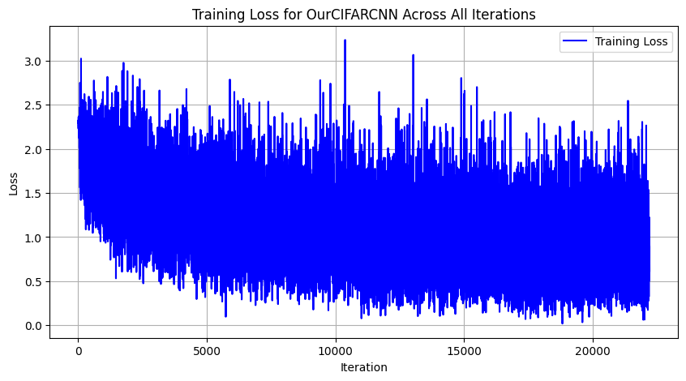

```python
# File paths for loading the model and losses
cnn_loss_file = '/content/drive/MyDrive/ECE57000_AI/Assignment_03/cifar_cnn_train_loss.pkl'  # Updated loss file name

# Load training losses
with open(cnn_loss_file, 'rb') as f:
    train_losses = pickle.load(f)

# Flatten the training losses across all epochs
flattened_losses = [loss for epoch_loss in train_losses for loss in epoch_loss]

# Calculate the total number of iterations (assuming batch size is known)
# You may need to replace `batch_size` with your actual batch size
total_iterations = len(flattened_losses)

# Generate x-axis values (iterations)
x_values = range(1, total_iterations + 1)

# Plot the training losses
plt.figure(figsize=(10, 5))
plt.plot(x_values, flattened_losses, label='Training Loss', color='blue')
plt.title('Training Loss for OurCIFARCNN Across All Iterations')
plt.xlabel('Iteration')
plt.ylabel('Loss')
plt.grid()
plt.legend()
plt.show()
```

```python
# File paths for loading model and losses
model_cnn_file = '/content/drive/MyDrive/ECE57000_AI/Assignment_03/cifar_cnn_model.pth'
criterion = nn.CrossEntropyLoss()
# Initialize the model
model = OurCIFARCNN()
# Load the trained model for testing
model.load_state_dict(torch.load(model_cnn_file))
model.eval()  # Set the model to evaluation mode

# Testing the model
test_stat  = test(model, criterion, test_loader)

# Print the testing loss and accuracy
print(f'Test Loss: {test_stat["loss"]:.3f}')
print(f'Test Accuracy: {test_stat["accuracy"]*100:.2f}%')
```

```
Test Loss: 0.894
Test Accuracy: 69.99%
```

### Task 3: Plot misclassified test images

Plot some misclassified images in your test dataset:

- select three images that are **misclassified** by your neural network
- label each images with true label and predicted label
- use `detach().cpu()` when plotting images if the image is in gpu

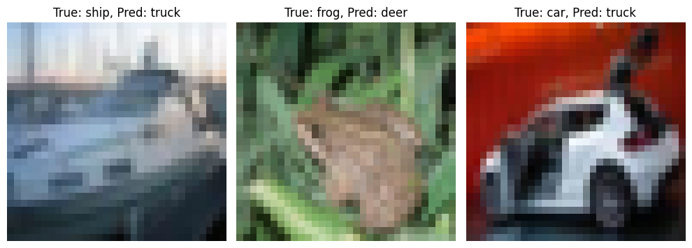

```python
total_images = 3
predictions = test_stat['prediction']
targets = torch.tensor(test_dataset.targets)
# ----------- <Your code> ---------------
# Find misclassified images
# CIFAR-10 class names
classes = ['plane', 'car', 'bird', 'cat', 'deer', 'dog', 'frog', 'horse', 'ship', 'truck']
misclassified = [(img, pred, true) for img, pred, true in zip(test_dataset.data, predictions, targets) if pred != true]

# Select the first three misclassified images
misclassified_images = misclassified[:total_images]

# Create a plot for the misclassified images
fig, axes = plt.subplots(1, 3, figsize=(10, 5))
for i, (img, pred, true) in enumerate(misclassified_images):
    ax = axes[i]

    # If image is on GPU, detach it and move to CPU
    img = torch.tensor(img).detach().cpu().numpy() if isinstance(img, torch.Tensor) else img

    # Plot image
    ax.imshow(img)
    ax.axis('off')

    # Set the title with true and predicted class names
    ax.set_title(f'True: {classes[true]}, Pred: {classes[pred]}')

# Display the plot
plt.tight_layout()
plt.show()
# ----------- <End Your code> ---------------
```

Questions (0 points): Are the mis-classified images also misleading to human eyes?

Two of them (Ship and Frog) are clearly misleading to human eyes. Car is also misleading, but can be identified by careful attention

## Exercise 3: Transfer Learning (30 points)

In practice, people won't train an entire CNN from scratch, because it is relatively rare to have a dataset of sufficient size (or sufficient computational power). Instead, it is common to pretrain a CNN on a very large dataset and then use the CNN either as an initialization or a fixed feature extractor for the task of interest.

In this task, you will learn how to use a pretrained CNN for CIFAR-10 classification.

### Task1: Load pretrained model

`torchvision.models` (https://pytorch.org/vision/stable/models.html) contains definitions of models for addressing different tasks, including: image classification, pixelwise semantic segmentation, object detection, instance segmentation, person keypoint detection and video classification.

First, you should load the **pretrained** ResNet-18 that has already been trained on [ImageNet](https://www.image-net.org/) using `torchvision.models`. If you are interested in more details about Resnet-18, read this paper https://arxiv.org/pdf/1512.03385.pdf.

```python
resnet18 = models.resnet18(pretrained=True)
resnet18 = resnet18.to(device)
```

### Task2: Create data loaders for CIFAR-10

Then you need to create a modified dataset and dataloader for CIFAR-10. Importantly, the model you load has been trained on **ImageNet** and it expects inputs as mini-batches of 3-channel RGB images of shape (3 x H x W), where H and W are expected to be **at least** 224. So you need to preprocess the CIFAR-10 data to make sure it has a height and width of 224. Thus, you should add a transform when loading the CIFAR10 dataset (see [`torchvision.transforms.Resize`](https://pytorch.org/vision/stable/transforms.html#torchvision.transforms.Resize)). This should be added appropriately to the `transform` you created in a previous task.

```python
# Create your dataloader here
# ----------- <Your code> ---------------
# Set the device (GPU or CPU)
device = torch.device('cuda' if torch.cuda.is_available() else 'cpu')

# Define the transform to resize the images and normalize
transform = transforms.Compose([
    transforms.Resize((224, 224)),               # Resize CIFAR-10 images to 224x224
    transforms.ToTensor(),                       # Convert images to PyTorch tensors
    transforms.Normalize(                        # Normalize with mean and std for ImageNet
        mean=[0.485, 0.456, 0.406],              # ImageNet mean for 3 channels (RGB)
        std=[0.229, 0.224, 0.225]                # ImageNet std for 3 channels (RGB)
    )
])

# Load the CIFAR-10 dataset with the transform applied
train_dataset = torchvision.datasets.CIFAR10(
    root='./data', train=True, download=True, transform=transform
)
test_dataset = torchvision.datasets.CIFAR10(
    root='./data', train=False, download=True, transform=transform
)

# Create data loaders
train_loader = torch.utils.data.DataLoader(train_dataset, batch_size=9, shuffle=True, num_workers=2)
test_loader = torch.utils.data.DataLoader(test_dataset, batch_size=9, shuffle=False, num_workers=2)
# ----------- <End Your code> ---------------
```

```
Files already downloaded and verified
Files already downloaded and verified
```

```python
# Modify the final layer to match the number of CIFAR-10 classes (10 classes)
num_ftrs = resnet18.fc.in_features
resnet18.fc = nn.Linear(num_ftrs, 10)
# Move the model to the appropriate device (GPU/CPU)
resnet18 = resnet18.to(device)

# Define loss function and optimizer
criterion = nn.CrossEntropyLoss()
optimizer = optim.SGD(resnet18.parameters(), lr=0.001, momentum=0.9)
```

```python
def train(model: nn.Module,
          loss_fn: nn.modules.loss._Loss,
          optimizer: torch.optim.Optimizer,
          train_loader: torch.utils.data.DataLoader,
          device: torch.device,
          epoch: int=0)-> List:
    # ----------- <Your code> ---------------
    model.train()  # Set the model to training mode
    train_loss = []  # To store loss for each batch

    # Loop over batches
    for batch_idx, (images, targets) in enumerate(train_loader):
        # Zero the gradients before forward pass
        optimizer.zero_grad()

        # Forward pass: compute predictions and loss
        outputs = model(images)
        loss = loss_fn(outputs, targets)

        # Backward pass: compute gradients
        loss.backward()

        # Update weights using optimizer
        optimizer.step()

        # Store loss for this batch
        train_loss.append(loss.item())

        # Print log 8-10 times per epoch
        if batch_idx % (len(train_loader) // 10) == 0:
            print(f'Epoch {epoch}: [{batch_idx*len(images)}/{len(train_loader.dataset)}] Loss: {loss.item():.3f}')
    # ----------- <End Your code> ---------------
    assert len(train_loss) == len(train_loader)
    return train_loss

def test(model: nn.Module,
         loss_fn: nn.modules.loss._Loss,
         test_loader: torch.utils.data.DataLoader,
         device: torch.device,
         epoch: int=0) -> Dict:
    model.eval()  # Set the model to evaluation mode
    test_loss = 0.0
    correct = 0
    predictions = []

    # Disable gradient computation for testing
    with torch.no_grad():
        for images, targets in test_loader:
            # Move images and targets to the appropriate device
            images, targets = images.to(device), targets.to(device)

            # Forward pass: compute predictions
            outputs = model(images)

            # Compute loss
            loss = loss_fn(outputs, targets)
            test_loss += loss.item()  # Accumulate the total loss

            # Get predictions: assuming classification task
            pred = outputs.argmax(dim=1, keepdim=True)  # Get index of the max log-probability
            predictions.append(pred.flatten())

            # Count correct predictions
            correct += pred.eq(targets.view_as(pred)).sum().item()

    # Convert predictions list to a 1D tensor
    predictions = torch.cat(predictions)

    # Average loss over all test data
    test_loss /= len(test_loader)

    # Accuracy calculation
    accuracy = correct / len(test_loader.dataset)

    # Create dictionary with test statistics
    test_stat = {
        "loss": test_loss,
        "accuracy": accuracy,
        "prediction": predictions
    }

    # Assertions for test statistics
    assert "loss" in test_stat.keys()
    assert "accuracy" in test_stat.keys()
    assert "prediction" in test_stat.keys()
    assert len(test_stat["prediction"]) == len(test_loader.dataset)
    assert isinstance(test_stat["prediction"], torch.Tensor)

    return test_stat
```

### Task3: Classify test data on pretrained model

*Use* the model you load to classify the **test** CIFAR-10 data and print out the test accuracy. Don't be surprised if the accuracy is bad!

```python
# ----------- <Your code> ---------------
# Set the model to evaluation mode
resnet18.eval()
# Test the model on CIFAR-10 test data
test_stat = test(resnet18, criterion, test_loader,device)
# ----------- <End Your code> ---------------
```

```python
# Print the testing loss and accuracy
print(f'Test Loss: {test_stat["loss"]:.3f}')
print(f'Test Accuracy: {test_stat["accuracy"]*100:.2f}%')
```

```
Test Loss: 2.520
Test Accuracy: 7.63%
```

### Task 4: Fine-tune (i.e., update) the pretrained model for CIFAR-10

Now try to improve the test accuracy. We offer several possible solutions:

(1) You can try to directly continue to train the model you load with the CIFAR-10 training data.

(2) For efficiency, you can try to freeze part of the parameters of the loaded models. For example, you can first freeze all parameters by

```
for param in model.parameters():
    param.requires_grad = False
```

and then unfreeze the last few layers by setting `somelayer.requires_grad=True`.

You are also welcome to try any other approach you can think of.

**Note:** You must print out the test accuracy and to get full credits, the test accuracy should be at least **80%**.

```python
# unfreeze the outer layers.
start = time.time()
#----------- <Your code> ---------------
for param in resnet18.parameters():
    param.requires_grad = False  # Freeze all pretrained layers

# Unfreeze the final layer (the last fully connected layer)
for param in resnet18.fc.parameters():
    param.requires_grad = True  # Only train the last layer

# Move the model to the appropriate device (GPU/CPU)
resnet18 = resnet18.to(device)

# Define loss function and optimizer
criterion = nn.CrossEntropyLoss()
optimizer = optim.SGD(resnet18.fc.parameters(), lr=0.001, momentum=0.9)  # Only optimize the FC layer

# File paths for saving model and losses
model_resnet_file = '/content/drive/MyDrive/ECE57000_AI/Assignment_03/resnet18_cifar.pth'  # Save the model
resnet_loss_file = '/content/drive/MyDrive/ECE57000_AI/Assignment_03/resnet18_train_loss.pkl'  # Save training losses

# Initialize training losses list
if os.path.exists(model_resnet_file) and os.path.exists(resnet_loss_file):
    resnet18.load_state_dict(torch.load(model_resnet_file))  # Load model weights
    with open(resnet_loss_file, 'rb') as f:
        resnet_train_losses = pickle.load(f)  # Load training losses
else:
    resnet_train_losses = []  # Initialize list if not present

# Training parameters
max_epoch = 4  # Number of epochs

# Training loop
start = time.time()

for epoch in range(1, max_epoch + 1):
    # Training the last layer using the train function
    epoch_loss = train_transfer_load(resnet18, criterion, optimizer, train_loader,device, epoch)
    resnet_train_losses.append(epoch_loss)  # Append the loss for this epoch

    # Save the model after each epoch
    torch.save(resnet18.state_dict(), model_resnet_file)

# Save the training losses to a file
with open(resnet_loss_file, 'wb') as f:
    pickle.dump(resnet_train_losses, f)

end = time.time()
print(f'Finished Training after {end - start} s')
```

[output not shown]

```python
# ----------- <Your code> ---------------
# Set the model to evaluation mode
resnet18.eval()
# Test the model on CIFAR-10 test data
test_stat = test(resnet18, criterion, test_loader,device)
# ----------- <End Your code> ---------------
```

```python
# Print the testing loss and accuracy
print(f'Test Loss: {test_stat["loss"]:.3f}')
print(f'Test Accuracy: {test_stat["accuracy"]*100:.2f}%')
```

```
Test Loss: 0.652
Test Accuracy: 81.02%
```

```python
#load another instance, train full model
resnet18_full_train = models.resnet18(pretrained=True)
um_ftrs = resnet18_full_train.fc.in_features
resnet18_full_train.fc = nn.Linear(num_ftrs, 10)
# Move the model to the appropriate device (GPU/CPU)
# Modify the final layer to match the number of CIFAR-10 classes (10 classes)
num_ftrs = resnet18_full_train.fc.in_features
resnet18_full_train.fc = nn.Linear(num_ftrs, 10)
# Move the model to the appropriate device (GPU/CPU)
resnet18_full_train = resnet18_full_train.to(device)

start = time.time()
#----------- <Your code> ---------------
for param in resnet18_full_train.parameters():
    param.requires_grad = True  # Freeze all pretrained layers

# Unfreeze the final layer (the last fully connected layer)
for param in resnet18_full_train.fc.parameters():
    param.requires_grad = True  # Only train the last layer

# Move the model to the appropriate device (GPU/CPU)
resnet18_full_train = resnet18_full_train.to(device)

# Define loss function and optimizer
criterion = nn.CrossEntropyLoss()
optimizer = optim.SGD(resnet18_full_train.fc.parameters(), lr=0.001, momentum=0.9)  # Only optimize the FC layer

# File paths for saving model and losses
model_resnet_file = '/content/drive/MyDrive/ECE57000_AI/Assignment_03/resnet18_full_train_cifar.pth'  # Save the model
resnet_loss_file = '/content/drive/MyDrive/ECE57000_AI/Assignment_03/resnet18_full_train_train_loss.pkl'  # Save training losses

# Initialize training losses list
if os.path.exists(model_resnet_file) and os.path.exists(resnet_loss_file):
    resnet18_full_train.load_state_dict(torch.load(model_resnet_file))  # Load model weights
    with open(resnet_loss_file, 'rb') as f:
        resnet_train_losses = pickle.load(f)  # Load training losses
else:
    resnet_train_losses = []  # Initialize list if not present

# Training parameters
max_epoch = 4  # Number of epochs

# Training loop
start = time.time()

for epoch in range(1, max_epoch + 1):
    # Training the full network using the train function
    epoch_loss = train(resnet18_full_train, criterion, optimizer, train_loader,device, epoch)
    resnet_train_losses.append(epoch_loss)  # Append the loss for this epoch

    # Save the model after each epoch
    torch.save(resnet18_full_train.state_dict(), model_resnet_file)

# Save the training losses to a file
with open(resnet_loss_file, 'wb') as f:
    pickle.dump(resnet_train_losses, f)

end = time.time()
print(f'Finished Training after {end - start} s')
```

```
Epoch 1: [0/50000] Loss: 2.846
Epoch 1: [4995/50000] Loss: 0.661
Epoch 1: [9990/50000] Loss: 1.412
Epoch 1: [14985/50000] Loss: 1.474
Epoch 1: [19980/50000] Loss: 0.871
Epoch 1: [24975/50000] Loss: 1.003
Epoch 1: [29970/50000] Loss: 0.273
Epoch 1: [34965/50000] Loss: 1.890
Epoch 1: [39960/50000] Loss: 0.956
Epoch 1: [44955/50000] Loss: 0.856
Epoch 1: [49950/50000] Loss: 1.031
Epoch 2: [0/50000] Loss: 0.817
Epoch 2: [4995/50000] Loss: 0.691
Epoch 2: [9990/50000] Loss: 0.424
Epoch 2: [14985/50000] Loss: 1.539
Epoch 2: [19980/50000] Loss: 0.445
Epoch 2: [24975/50000] Loss: 1.147
Epoch 2: [29970/50000] Loss: 0.650
Epoch 2: [34965/50000] Loss: 1.158
Epoch 2: [39960/50000] Loss: 0.999
Epoch 2: [44955/50000] Loss: 0.798
Epoch 2: [49950/50000] Loss: 0.375
Epoch 3: [0/50000] Loss: 0.880
Epoch 3: [4995/50000] Loss: 0.215
Epoch 3: [9990/50000] Loss: 0.651
Epoch 3: [14985/50000] Loss: 0.136
Epoch 3: [19980/50000] Loss: 1.523
Epoch 3: [24975/50000] Loss: 0.425
Epoch 3: [29970/50000] Loss: 1.304
Epoch 3: [34965/50000] Loss: 0.995
Epoch 3: [39960/50000] Loss: 0.308
Epoch 3: [44955/50000] Loss: 0.626
Epoch 3: [49950/50000] Loss: 0.890
Epoch 4: [0/50000] Loss: 1.107
Epoch 4: [4995/50000] Loss: 1.127
Epoch 4: [9990/50000] Loss: 1.762
Epoch 4: [14985/50000] Loss: 0.810
Epoch 4: [19980/50000] Loss: 0.638
Epoch 4: [24975/50000] Loss: 0.302
Epoch 4: [29970/50000] Loss: 0.858
Epoch 4: [34965/50000] Loss: 0.340
Epoch 4: [39960/50000] Loss: 0.475
Epoch 4: [44955/50000] Loss: 1.001
Epoch 4: [49950/50000] Loss: 0.720
Finished Training after 818.0664708614349 s
```

```python
# ----------- <Your code> ---------------
# Set the model to evaluation mode
resnet18.eval()
# Test the model on CIFAR-10 test data
test_stat = test(resnet18_full_train, criterion, test_loader, device)
# Print the testing loss and accuracy
print(f'Test Loss: {test_stat["loss"]:.3f}')
print(f'Test Accuracy: {test_stat["accuracy"]*100:.2f}%')
# ----------- <End Your code> ---------------
```

[output not shown]